# Hello world - algorithmic trading with Python using quantopian platform

## sharpe ratio

`sharpe ratio is excess return per unit of the risk assumed`

$$ sharpe\,ratio = \frac {(R_p - R_f)}{\sigma_p} $$$$ R_p = Return \,of \,the \,portfolio, R_f = Risk\, free\, rate, \sigma_p = volatility \,or \,std \,deviation\, of portfolios \,excess \,return $$

The Sharpe ratio adjusts a portfolio’s past performance—or expected future performance—for the excess risk that was taken by the investor. A high Sharpe ratio is good when compared to similar portfolios or funds with lower returns. The Sharpe ratio has several weaknesses including an assumption that investment returns are normally distributed.

The Sharpe ratio can be used to evaluate a portfolio’s past performance (ex-post) where actual returns are used in the formula. Alternatively, an investor could use expected portfolio performance and the expected risk-free rate to calculate an estimated Sharpe ratio (ex-ante).

The Sharpe ratio can also help explain whether a portfolio's excess returns are due to smart investment decisions or a result of too much risk.

The greater a portfolio's Sharpe ratio, the better its risk-adjusted performance. If the analysis results in a negative Sharpe ratio, it either means the risk-free rate is greater than the portfolio’s return, or the portfolio's return is expected to be negative. In either case, a negative Sharpe ratio does not convey any useful meaning.

Source: Investopedia

```python
empyrical.sharpe_ratio(backtest_daily_returns)
```

```
0.49748492912656744
```

```python
empyrical.sharpe_ratio(benchmark_daily_returns)
```

```
-0.05304171546593008
```

`The Sharpe ratio can be manipulated by portfolio managers seeking to boost their apparent risk-adjusted returns history. This can be done by lengthening the rolling window interval. This will result in a lower estimate of volatility.`

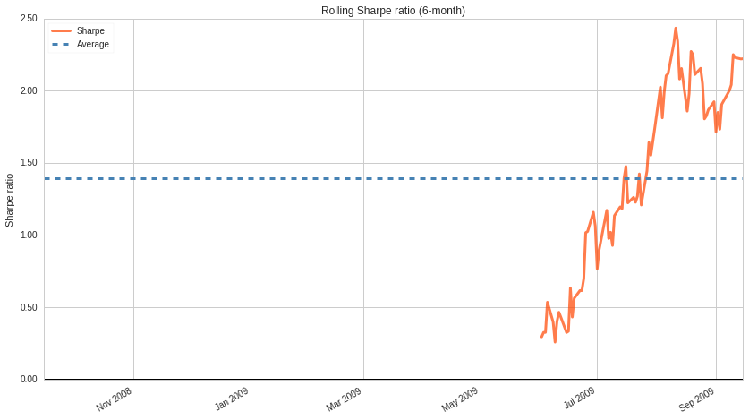

```python
pyfolio.plot_rolling_sharpe(backtest_daily_returns, rolling_window=180); # Rf = 0 in quantopian
```

## beta

```python
empyrical.beta(backtest_daily_returns, benchmark_daily_returns)
```

```
1.0152117020774396
```

## rolling beta

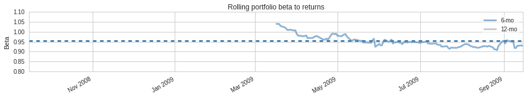

```python
fig,ax =plt.subplots(figsize=(15,2))
pyfolio.plot_rolling_beta(backtest_daily_returns, benchmark_daily_returns, ax=ax);
plt.ylim((0.8,1.1));
```

## daily returns

`observe the volatility this is the start of 2008 crisis`

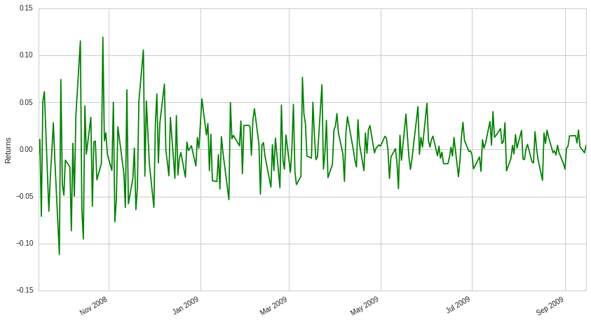

```python
pyfolio.plotting.plot_returns(backtest_daily_returns);
```

## cumulative returns

`cumulative returns gives overall returns relative to 100% of the position at initiation`

`cumulative plots also compare with the benchmark`

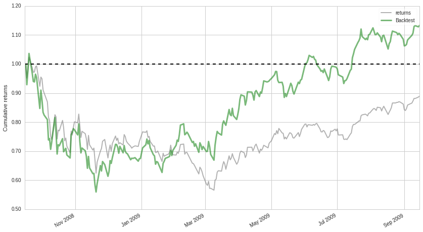

```python
pyfolio.plotting.plot_rolling_returns(backtest_daily_returns,benchmark_daily_returns);
```

## gross leverage

`Gross leverage is the sum of long and short exposure per share divided by net asset value.`

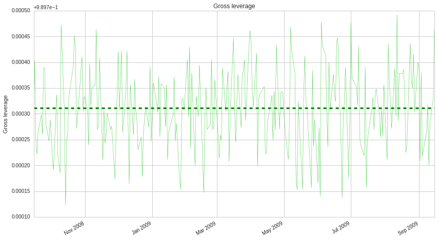

```python
pyfolio.plot_gross_leverage(backtest_daily_returns, backtest_positions);
```

## annual returns, monthly return distribution, monthly returns heatmaps of the portfolio

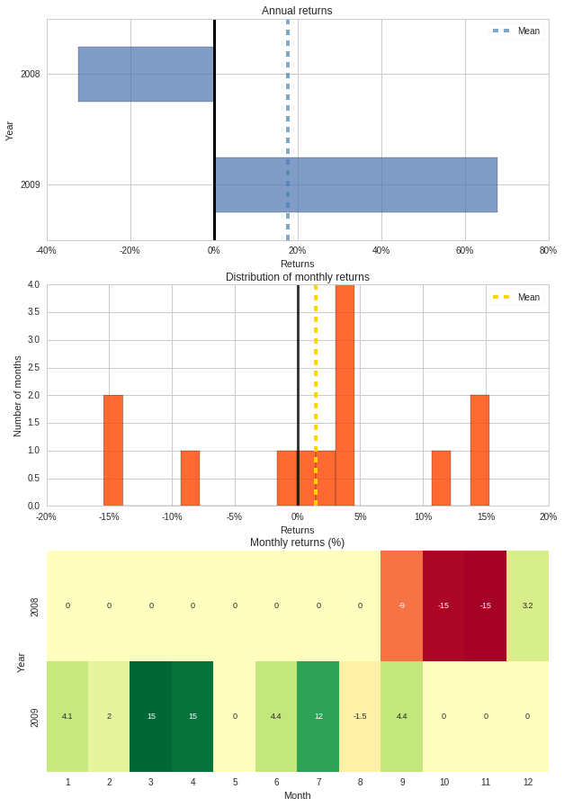

```python
fig, ax = plt.subplots(nrows=3,ncols=1,figsize=(10,15))
pyfolio.plot_annual_returns(backtest_daily_returns, ax=ax[0]); # returns annual
pyfolio.plot_monthly_returns_dist(backtest_daily_returns, ax=ax[1]); # distribution of monthly returns
pyfolio.plot_monthly_returns_heatmap(backtest_daily_returns, ax=ax[2]); # monthly heatmaps showing returns
```

## quantile distribution of returns

`quantile distribution provides quantiles for monthly daily and weekly returns`

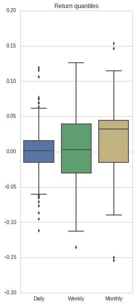

```python
fig,ax =plt.subplots(figsize=(4,10))
pyfolio.plot_return_quantiles(backtest_daily_returns, ax=ax);
```

`we can observe the ouliers near the wicks which are very important for a credit analyst`

## drawdown periods

`top 4 drawdown periods relative to 100% at initiation`

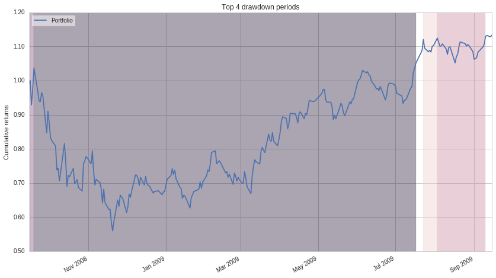

```python
pyfolio.plot_drawdown_periods(backtest_daily_returns, top=4);
```

## drawdown-underwater plots

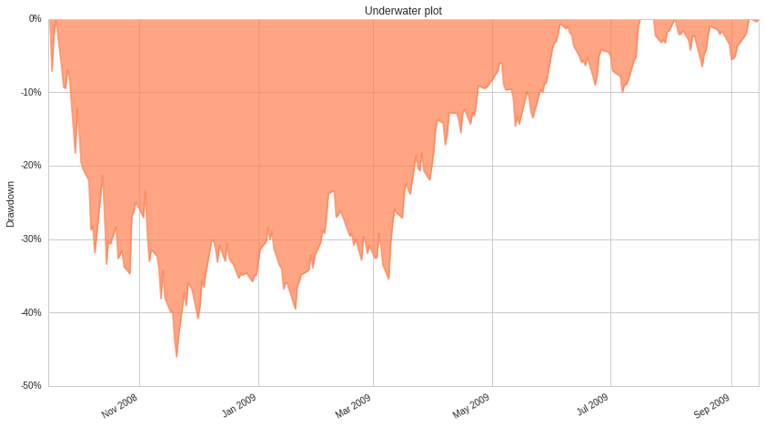

```python
pyfolio.plot_drawdown_underwater(backtest_daily_returns); # underwater plots in percentage
```

## allocations and positions overview

| Top 10 long positions of all time | max |
| --- | --- |
| AMZN-16841 | 33.57% |
| CSCO-1900 | 33.34% |
| AAPL-24 | 33.30% |

| Top 10 short positions of all time | max |
| --- | --- |

| Top 10 positions of all time | max |
| --- | --- |
| AMZN-16841 | 33.57% |
| CSCO-1900 | 33.34% |
| AAPL-24 | 33.30% |

| All positions ever held | max |
| --- | --- |
| AMZN-16841 | 33.57% |
| CSCO-1900 | 33.34% |
| AAPL-24 | 33.30% |

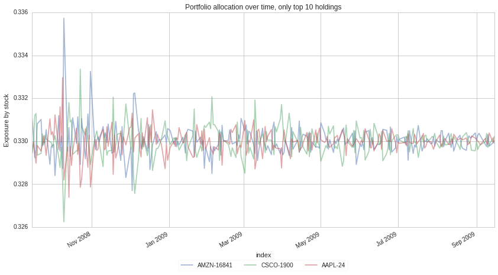

```python
position_percentage =  pyfolio.pos.get_percent_alloc(backtest_positions)
pyfolio.plotting.show_and_plot_top_positions(backtest_daily_returns,position_percentage);
```

# Full tear sheet

| Start date End date In-sample months Out-of-sample months | 2008-09-15 2009-09-15 3 8 All | 2008-09-15 2009-09-15 3 8 In-sample | 2008-09-15 2009-09-15 3 8 Out-of-sample | 2008-09-15 2009-09-15 3 8 |
| --- | --- | --- | --- | --- |
| Annual return | 13.2% | -72.8% | 109.1% |  |
| Cumulative returns | 13.3% | -32.5% | 67.9% |  |
| Annual volatility | 50.9% | 75.3% | 35.4% |  |
| Sharpe ratio | 0.50 | -1.36 | 2.26 |  |
| Calmar ratio | 0.29 | -1.58 | 6.92 |  |
| Stability | 0.59 | 0.57 | 0.91 |  |
| Max drawdown | -46.0% | -46.0% | -15.8% |  |
| Omega ratio | 1.09 | 0.80 | 1.45 |  |
| Sortino ratio | 0.73 | -1.89 | 3.74 |  |
| Skew | 0.14 | 0.33 | 0.28 |  |
| Kurtosis | 1.87 | 0.09 | 0.49 |  |
| Tail ratio | 0.96 | 0.97 | 1.30 |  |
| Daily value at risk | -6.3% | -9.9% | -4.1% |  |
| Gross leverage | 0.99 | 0.99 | 0.99 |  |
| Daily turnover | 22.1% | 37.1% | 15.7% |  |
| Alpha | 0.31 | -0.15 | 0.52 |  |
| Beta | 1.01 | 1.03 | 0.96 |  |

| Worst drawdown periods | Net drawdown in % | Peak date | Valley date | Recovery date | Duration |
| --- | --- | --- | --- | --- | --- |
| 0 | 46.00 | 2008-09-19 | 2008-11-20 | 2009-07-17 | 216 |
| 1 | 7.11 | 2008-09-16 | 2008-09-17 | 2008-09-19 | 4 |
| 2 | 6.47 | 2009-08-03 | 2009-08-17 | 2009-09-10 | 29 |
| 3 | 3.28 | 2009-07-23 | 2009-07-29 | 2009-08-03 | 8 |
| 4 | 0.36 | 2009-09-11 | 2009-09-14 | 2009-09-15 | 3 |

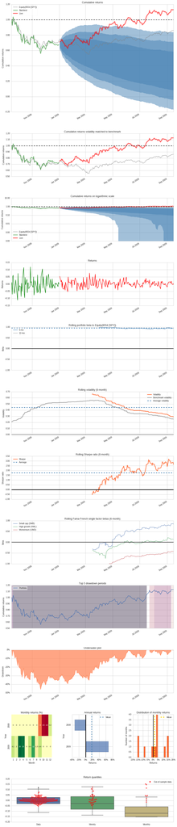

| Stress Events | mean | min | max |
| --- | --- | --- | --- |
| Lehmann | -0.87% | -11.18% | 7.43% |
| Sept08 | -0.87% | -11.18% | 7.43% |
| 2009Q1 | 0.19% | -5.35% | 5.37% |
| 2009Q2 | 0.54% | -4.18% | 7.67% |
| GFC Crash | -0.04% | -11.18% | 11.92% |
| Recovery | 0.29% | -4.18% | 4.91% |

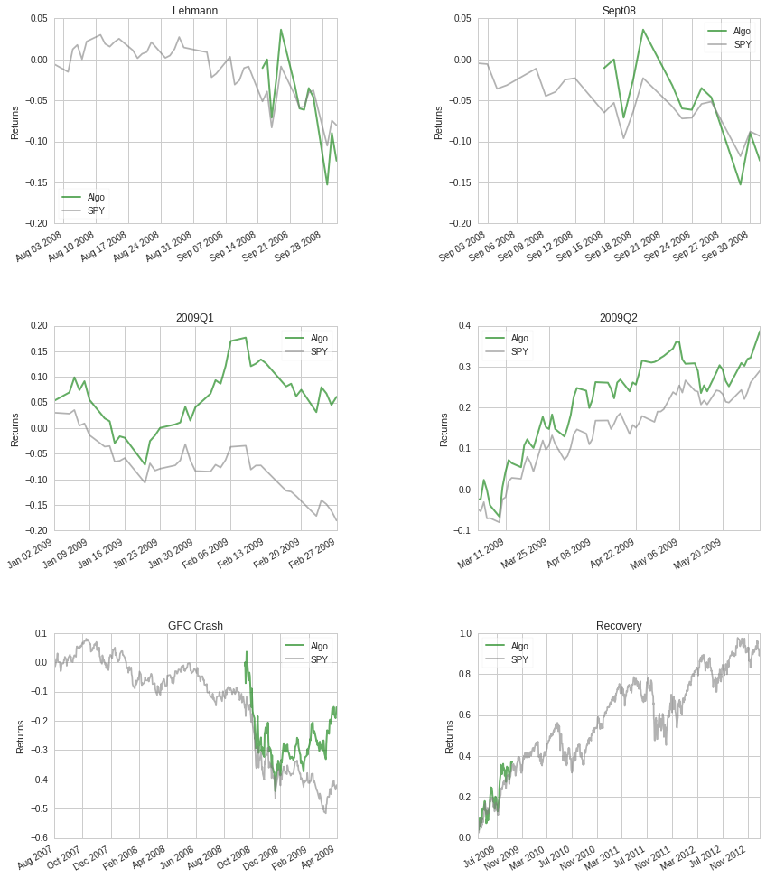

| Top 10 long positions of all time | max |
| --- | --- |
| AMZN-16841 | 33.57% |
| CSCO-1900 | 33.34% |
| AAPL-24 | 33.30% |

| Top 10 short positions of all time | max |
| --- | --- |

| Top 10 positions of all time | max |
| --- | --- |
| AMZN-16841 | 33.57% |
| CSCO-1900 | 33.34% |
| AAPL-24 | 33.30% |

| All positions ever held | max |
| --- | --- |
| AMZN-16841 | 33.57% |
| CSCO-1900 | 33.34% |
| AAPL-24 | 33.30% |

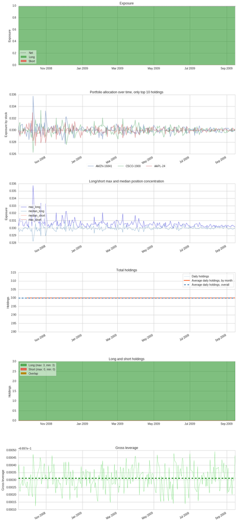

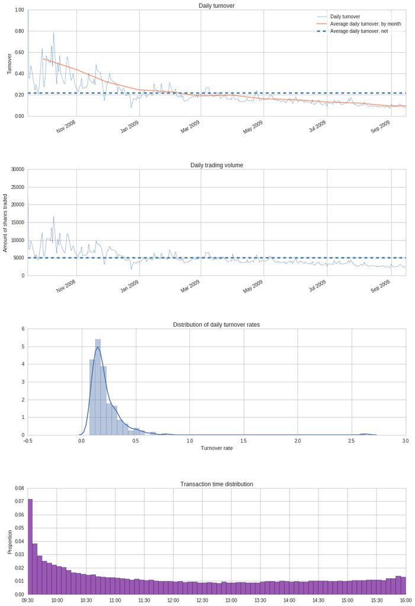

[output not shown]

```python
pyfolio.create_full_tear_sheet(backtest_daily_returns,
                               backtest_positions,backtest_transactions,
                               benchmark_daily_returns,
                               live_start_date='2009-01-01')
```

`References: www.investopedia.com , www.quantopian.com, wikipedia`